# **Comparison of fungal analyses**

Current KSU fungal analyses vs. Rudgers 2021

Kelli Feeser

2024-01-02

**Previous manuscript**  
Rudgers, J.A., Fox, S., Porras‐Alfaro, A., Herrera, J., Reazin, C., Kent, D.R., Souza, L., Chung, Y.A., & Jumpponen, A. (2022). Biogeography of root‐associated fungi in foundation grasses of North American plains. Journal of Biogeography, 49(1), 22-37. doi/10.1111/jbi.14260

[figure not shown]

# 1 Sequencing and OTU clustering results

| Sequencing Stats | Rudgers2021 | Current | Improvement (%) |
| --- | --- | --- | --- |
| Total Reads | 48,000,648 | 30,012,559 | -37.47 |
| Clean Reads | 20,716,515 | 18,230,837 | -12 |
| Mean Read Count | 30,376 | 42,571 | 40.15 |
| SD Read Count | 26,066 | 57,199 | 119.44 |
| Rarefaction Level | 10,000 | 10,116 | 1.16 |
| Fungal OTU Count | 7,608 | 6,749 | -11.29 |

*Note*: I did further cleaning of the dataset reducing the number of clean reads to 5,149,044, however I am reporting the value that corresponds to the processing steps by Rudgers et al. Also, Rudgers 2021 included all EDGE samples for their analyses. I can go back and remove EDGE samples from their analyses to make this more comparable if need be.

| Sequencing Coverage | Rudgers2021 | Current | Improvement (%) |
| --- | --- | --- | --- |
| Good’s Coverage (mean ± SD) | 0.994 ± 0.003 | 0.997 ± 0.003 | 0.3 |

# 2 Diversity & composition analyses

**Diversity definitions**

- Rudgers2021 used Mothur for calculating alpha diversity. Mothur differs from vegan in calculating some metrics, so I am explicitly defining the equations used by Rudgers2021 and these current analyses.
- *Species Richness* (observed species)
  - $S_{obs} = \sum_ix_i$
    - $x_i$ is a numeric vector of species counts per sample
      - Equivalents
        - `estimate_richness()` R package `vegan 2.6-4` with `measures = "Observed"` (I used this)
- *Simpson* (unbiased estimate of dominance index)
  - $D_{simpson} = \sum_ip^2_i$, where $p_i$ is the species proportion and $N$ is the total number of counts (i.e., the rarefaction depth - 10,116 sequences/sample in our data)
    - $p_i = x_i(x_i - 1)/(N(N - 1))$
    - Approximate equivalents (these use a different calculation for $p_i$ ($p_i = x_i/N$))
      - `simpson` calculator in Mothur
      - `dominance()` in `skbio.diversity.alpha`
      - `dominance()` in R package `abdiv 0.2.0`
      - 1 - `diversity()` in R package `vegan 2.6-4` with `index = "simpson"`
      - 1 - `estimate_richness()` R package `vegan 2.6-4` with `measures = "Simpson"` (I used this)
- *Inverse Simpson* (the probability of selecting two individuals from different species, with replacement, using an unbiased estimate of dominance index)
  - Notably, this is defined as $1 - D_{simpson}$, *not* $1/D_{simpson}$
    - Approximate equivalents
      - `?` calculator in Mothur
      - `simpson()` in `skbio.diversity.alpha`
      - `simpson()` in R package `abdiv 0.2.0`
      - `diversity()` in R package `vegan 2.6-4` with `index = "simpson"`
      - `estimate_richness()` R package `vegan 2.6-4` with `measures = "Simpson"` (I used this)
- *Simpson evenness* (inverse Simpson index divided by the theoretical maximum diversity)
  - $E_{simpson} = 1 / (D_{simpson}*S_{obs})$
    - The logic is that in a perfectly even community (all OTUs are present in equal ratios), the $D_{simpson}$ would just be $1/(S_{obs})$ so any deviation in the observed $D_{simpson}$ from this value is the result of uneveness.
    - Approximate equivalents
      - `simpsoneven` calculator in Mothur
      - `simpson_e()` in skbio.diversity.alpha
      - `simpson_e()` in R package `abdiv 0.2.0`
      - Derived from $D_{simpson}$ (using `diversity()` in R package `vegan 2.6-4` with `index = "simpson"` or `estimate_richness()` in R package `vegan 2.6-4` with `measures = "Simpson"`).
        - I used the latter, then applied the above equation ($E_{simpson} = 1 /(D_{simpson}*S_{obs})$)
- *Shannon*
  - $H_{shannon} = -\sum\limits_ip_i log p_i$, where $p_i$ is the species proportion
    - $p_i = x_i(x_i - 1)/(N(N - 1))$
    - Equivalents
      - `shannon` calculator in Mothur
      - `shannon()` in `skbio.diversity.alpha`
      - `shannon()` in R package `abdiv 0.2.0` (I used this)
      - `diversity()` in R package `vegan 2.6-4` with `index = "shannon"`
      - `estimate_richness()` R package `vegan 2.6-4` with `measures = "Shannon"` (I used this)
- *Shannon evenness* (Shannon index divided by the theoretical maximum diversity, aka Pielou’s Evenness index)
  - $E_{shannon} = H_{shannon}/ln(S_{obs})$
    - Equivalents
      - `shannoneven` calculator in Mothur
      - `peilou_e()` in `skbio.diversity.alpha`
      - `pielou_e()` in R package `abdiv 0.2.0` (I used this)
      - Derived from $H_{shannon}$ (using `diversity()` in R package `vegan 2.6-4` with `index = "shannon"` or `estimate_richness()` in R package `vegan 2.6-4` with `measures = "Shannon"`) (I used the latter)
        - In R, $E_{shannon} = H_{shannon}/log(S_{obs})$
          - note that in R, `log` is the natural logarithm, the typical base 10 logarithm is invoked with `log10`

## 2.1 Analysis (1) Does the diversity, composition or abundance of root-associated fungi vary with latitude and are latitudinal gradients similar across host plant species?

### 2.1.1 Methods: GLMs

**GLM -** General linear mixed-effects models

- Responses
  - diversity ($1 - D_{simpson}$; “inverse Simpson” per Rudgers 2021)
  - richness ($S_{obs}$; species richness)
  - evenness ($E_{simpson} = 1 / (D_{simpson}*S_{obs})$; Simpson’s evenness)
  - root colonisation (fungal abundance in host tissue)
- Predictors
  - latitude
  - plant species identity
  - the species × latitude interaction.
- Models included the random effects of east-west gradient identity and site nested within gradient (Table S1)
- Secondary analysis
  - Significant grass species ×latitude interactions were decomposed via secondary analysis for each grass species.
- Other notes
  - The model for B. eriopoda, which occurred only on the western gradient, lacked the gradient random effect. We chose the best linear or quadratic model for latitude using the second-order Akaike’s Information Criterion (AICc). Analyses met assumptions of normality of residuals and homogeneity of variances following square-root transformation of evenness and log-transformation of root colonisation.
- Cite: using the lmer function in (Bates et al., 2015; R Core Team, 2020).

### 2.1.2 Results: diversity ~ latitude (GLM)

*Diversity = species richness and evenness

- Linear poleward decline

The expected linear poleward decline in **richness** occurred only in *A. gerardii* (Figure 2a (below), Table 1).

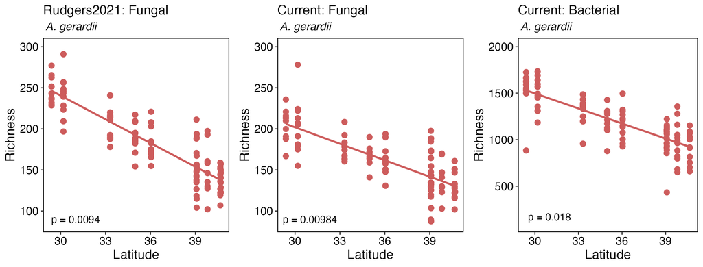

Figure 2a

- Latitudinal “U” pattern

In *B. dactyloides*, fungal OTU **richness** peaked at the highest and lowest latitudes (Figure 2b, Table 1, quadratic), and fungal **evenness** had a similar latitudinal “U” pattern in *B. gracilis* (Figure 2i).

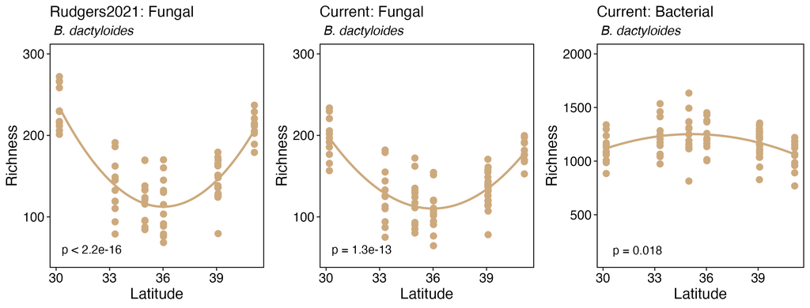

Figure 2b

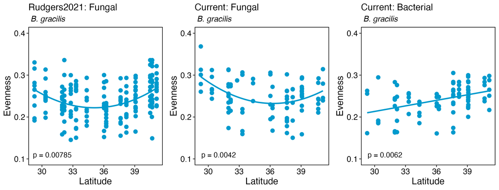

Figure 2i

- Latitudinal inverse “U” pattern

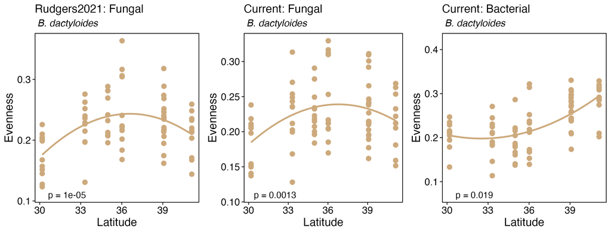

Figure 2g

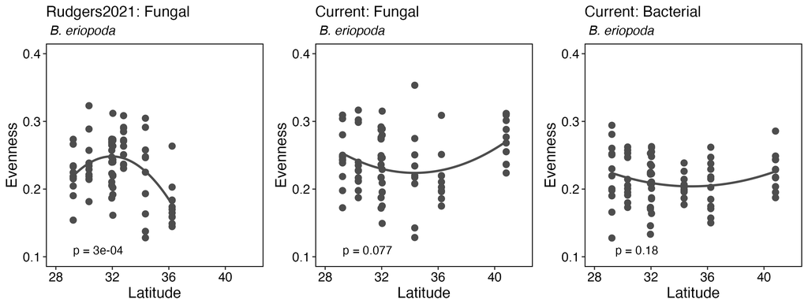

Figure 2h

*Note for Figure 2h (B. eriopoda evenness):* We have an additional site vs Rudger2021, but I’m not sure why. The site is Central Plains Experimental Range (CPR) at 40.81553 latitude. Conversely we are also missing a site that they had - Gile National Forest (GNF) at 31.95908 latitude. We have this site covered in other grass host species? We both have the same number of *B. eriopoda* samples (n=78). Not sure what’s going on here… maybe an EDGE site?

“We [Rudgers2021] tested for latitudinal gradients in fungal composition using perMANOVA in Primer v. 6.1.10 on the Bray-Curtis distance from the matrix of rarefied proportional abundances of each fungal OTU (Clarke & Gorley, 2015). We binned sites into categories (North, North-Central, South-Central, or South, Table S1) to overcome the perMANOVA restriction to categorical variables. Models included latitude, grass species identity, species × latitude and the random effects of east-west gradient and site nested in gradient. We then ran distance-based linear models (DIST-LM) for each grass species individually using latitude as a continuous rather than categorical variable (Clarke & Gorley, 2015).”

Note: I did this in R, not Primer

### 2.1.4 Results: root colonization ~ latitude (GLM)

*root colonization = fungal abundance in host tissue

[Analysis not re-done]

## 2.2 Analysis (2) Does the composition of non-mycorrhizal root-associated fungi converge near host range edges?

“We used permDISP to examine divergence among individual plants in fungal composition (Clarke & Gorley, 2015) and to test the hypothesis that fungal composition was more homogenous among plants nearing the hosts’ latitudinal range edge. Models for each host grass compared dispersion among latitudinal categories (North, North-Central, South-Central or South), each containing similar numbers of samples (Table S1)”

## 2.3 Analysis (3) What is the relative importance of climate, edaphic factors, or host traits as predictors of root-associated fungal community structure?

### 2.3.1 Methods: GDMs

**GDMs -** Generalized dissimilarity models of tabular site-pair data

We examined environmental correlates of root-associated fungal community structure for each grass species. For fungal composition, we calculated the site average for the rarefied proportional abundance of each fungal OTU to build Generalized Dissimilarity Models (GDM) (e.g. Glassman et al., 2017) that account for spatial non-independence among sites using latitude and longitude coordinates.

GDMs examine how species turnover increases with spatial distance among sites, and their I-splines describe nonlinear relationships between fungal composition and environmental variables.

- This approach is particularly important because the same unit increase in, for example, soil moisture may matter more in dry sites than wet sites, producing a nonlinear relationship to fungal composition.
- Each GDM included 3 climatic variables (annual precipitation, growing degree days and soil gravimetric water content), 3 edaphic variables (soil pH, ammonium and total phosphorus) and 3 plant traits (SLA, SRL and folivory) to give equal weight to each category of predictor.
- We eliminated multicollinearity by removing correlated predictors, retaining ammonium over nitrate and soil pH over SOM based on initial univariate analyses.
- All predictors were scaled to mean = 0 and SD = 1.
- We obtained p-values for best models via backward selection in gdm.varImp (Ferrier et al., 2007).

> basic GDM code:

> ```
>   all_gdm <- formatsitepair(otu_gdm,1, dist="bray", abundance=TRUE, siteColumn="sample", XColumn="longitude", YColumn="latitude", predData=env_gdm, weightType="equal")
>   m.all <- gdm(all_gdm,geo=TRUE)
>
>   ## get splines for best model (P<0.05) modall
>   gdm.varImp(all_gdm,geo=TRUE,parallel=TRUE,nPerm=100)
> ```

### 2.3.2 Results: composition ~ latitude (GDMs)

| GDM summary | Rudgers2021: Fungal | Current: Fungal | Current: Bacterial | Term explaination |
| --- | --- | --- | --- | --- |
| Data subset | all host species | all host species | NA | NA |
| nsamples | 1596 | NA | NA | NA |
| Geographical distance used in model fitting? | TRUE | TRUE | NA | if TRUE, geographic distance between sites is included as a model term |
| NULL Deviance | 119.71 | NA | NA | the deviance of the null model |
| GDM Deviance | 99.414 | NA | NA | the deviance of the fitted GDM model |
| Percent Deviance Explained | 16.954 | NA | NA | the percentage of null deviance explained by the fitted GDM model |
| Model p-value | 0.01 | not run yet | NA | NA |
| Predictor Order by Sum of I-Spline Coefficients | NA | NA | NA | predictors that were used to fit the model, in order of the amount of turnover associated with each predictor (based on the sum of the I-spline coefficients) |
| Predictor 1 (Sum of Coefficients for P1) | Edaphic: pH (0.472) | NA | NA | category: predictor (sum of I-spline coefficients for predictor) |
| Predictor 2 (Sum of Coefficients for P2) | Geographic coords (0.461) | NA | NA | NA |

[output cut: 9 more lines]

# 3 Figures

## NMDS by Grass Host (Figure 1B)

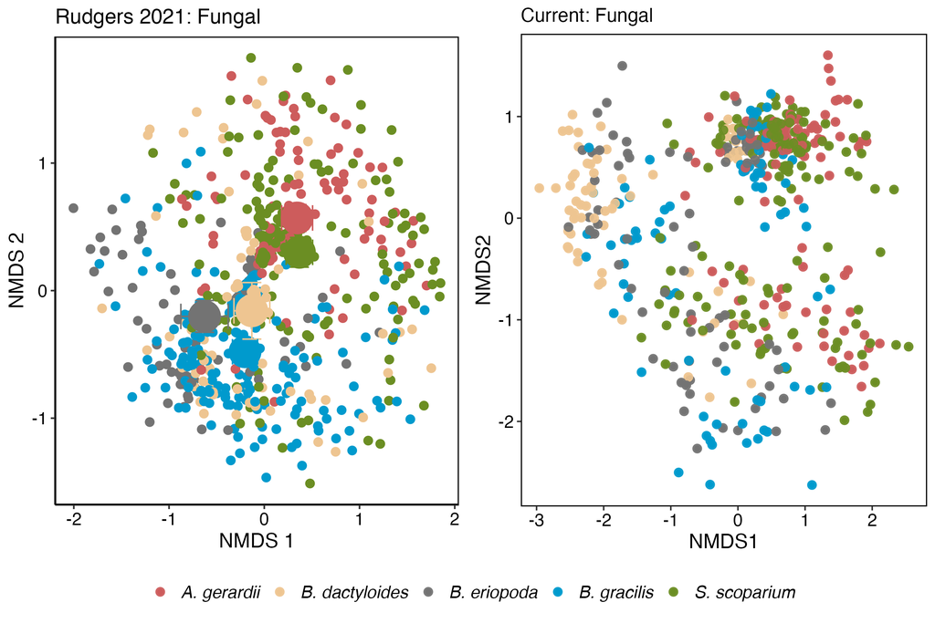

*Note:* Rudgers 2021 reports a stress of 0.26 (for *k* = 3) which I would strongly consider to be too high (guidelines: >0.2 is poor (risks for false interpretation), 0.1 - 0.2 is fair (some distances can be misleading for interpretation), 0.05 - 0.1 is good (can be confident in inferences from plot), and <0.05 is excellent (this can be rare)). I created this ordination with a higher *k* value of 5 and resulting stress of 0.11.